# The Society for Conservation Biology

[Conservation Biology](https://conbio.onlinelibrary.wiley.com/journal/15231739)

[Volume 18, Issue 2](https://conbio.onlinelibrary.wiley.com/toc/15231739/2004/18/2)

[figure not shown]

Full Access

# Recovery of Faunal Communities During Tropical Forest Regeneration

## Recuperación de Comunidades de Fauna Durante la Regeneración del Bosque Tropical

[ROBERT R. DUNN](https://conbio.onlinelibrary.wiley.com/action/doSearch?ContribAuthorStored=DUNN%2C+ROBERT+R)

* Current address: Department of Environmental Biology, Curtin University of Technology, Bently, WA 6102, Australia, email

First published: 19 March 2004

https://doi.org/10.1111/j.1523-1739.2004.00151.x

Citations: 160

## Abstract

**Abstract:** *As mature tropical forests are cleared, secondary forests may play an important role in the conservation of animal species, depending on how fast animal communities recover during forest regeneration. I reviewed published studies on the recovery of animal species richness and composition during tropical forest regeneration. In 38 of the 39 data sets I examined, conversion of forest to agriculture or pasture substantially reduced species richness. Given suitable conditions for forest recovery, the species richness of the animal taxa considered can be predicted to resemble that of mature forests roughly 20–40 years after land abandonment. At least for ants and birds, however, recovery of species composition appears to take substantially longer than recovery of species richness. Because species richness for many taxa appears to recover relatively rapidly in secondary forests, conservation of secondary forests may be an effective investment in future diversity. The slower recovery of species composition indicates, however, that some species will require stands of mature forest to persist.*

## Introduction

Throughout the tropics, deforestation due to logging, agriculture, and cattle ranching continues to cause a net decrease in forest cover each year (Food and Agriculture Organization 1999). Typically, however, converted land is exhausted, abandoned, and allowed to regrow (Nepstad et al. 1991). As a result, secondary forests make up an increasing percentage of total forest cover. For some countries, secondary forest may soon be all that remains (Castelletta et al. 2000). While conservation emphasis has been on establishing reserves that protect mature forests, the importance of disturbed areas such as secondary forest for conservation of fauna has been increasingly recognized (Vandermeer & Perfecto 1997; Gascon et al. 1999).

If the species richness and composition of animal communities recovers within a few decades, conserving secondary forest may help conserve animal species where mature forest is nonexistent, expensive, or impractical to conserve. Furthermore, diverse secondary forests may provide other conservation services by buffering reserves against climatic changes or invasion by exotic species. On the other hand, if animal communities take centuries to recover, secondary forests may be long‐term sinks for many species. Slow recovery of animal communities during forest regeneration can in some cases even hinder the recovery of plant communities and ecosystem processes (Wunderle 1997; Moutinho 1998; Davies et al. 1999).

Many studies have examined the recovery of animal communities during forest regeneration, but, due to their small spatial and temporal scales, often with no replication, these studies are of limited generality. By reviewing papers published to date, I explored our knowledge of the recovery of animal communities during tropical forest regeneration. In particular, I examined patterns of community recovery during forest regeneration and I tested whether the two most frequently studied taxa, birds and ants, differ in their recovery rates. I also examined whether the species richness of ants and birds recovers more quickly than their species composition.

## Methods

I searched for published studies that examined the relationship between forest clearance and regeneration and the species richness and species composition of particular taxa in tropical rainforest regions. I located papers on Web of Science (1994–2001) and Cambridge Scientific Abstracts (1982–2001) through the key words *disturbance*, *secondary forest, succession, pasture,* and *logging.* I then used the references found in those papers to locate other studies. Logged sites were included if they had been clearcut, but not if they had been logged selectively. I excluded studies that did not report any measure of species richness or species density. In all cases, the studies I selected compared the responses of focal taxa across a chronosequence of sites of known ages. Though not experiments, chronosequences are often used as proxies for experimental data (e.g., Foster & Tilman 2000).

I distinguished between three successional stages: mature forests, secondary forests, and cleared areas such as pastures, logged sites, or cultivated land. In deciding whether a forest was mature or not, I used the authors' descriptions of their field sites. In some studies, authors collected land‐use history of mature forests from interviews with local people (e.g., Shankar Raman et al. 1998). In other studies, authors based land‐use history on floristics (e.g., Johns 1991) or the presence of a high canopy (e.g., Belshaw & Bolton 1993). In most cases, however, authors did not describe how they chose mature forest sites. Given the long history of human presence in most tropical forests (Denevan 1992), it is probable that most of the mature forest sites I included had been anthropogenically altered in some way. A few of the mature forest stands were selectively logged in the past (Bloemers et al. 1997; Lawton et al. 1998). In other cases, mature forest sites may have been affected by precolonial agriculture or harvesting (Denevan 1992; Stahl 1994). Nonetheless, whether identified through floristics or local history, such “mature forests” are the primary targets of conservation agencies and thus serve as a practical baseline.

To compare the results of different studies, I converted the species richness of each taxon in each cleared area and secondary forest to a standardized species richness value. Standardized species richness in each successional stage at each site was measured as a percentage of the mature forest richness at that site. Thus, standardized richness can be greater than 100% when a secondary forest plot is more diverse than the corresponding mature forest. Site age, measured in years since abandonment, was log‐transformed for all analyses (log<sub>10</sub>[forest age + 1]) so that linear‐regression techniques could be used to examine the correlation between forest age and standardized species richness.

I compared the percent similarity in species composition among successional stages at each site by using the Morisita‐Horn index (Magurran 1988), which is a measure of the similarity in species composition and relative abundance between samples, where higher values indicate greater similarity, with a maximum of one. Authors presented Morisita‐Horn values in some of the studies I included, and I was able to calculate values based on the data presented in the appendices of several other studies.

To examine how quickly, or if, species composition recovers to mature‐forest levels during forest regeneration, I measured the similarity of secondary forests of different ages to corresponding mature forests. I compared the effects of forest clearance and subsequent vegetative succession on the species composition of ants and birds by using randomization‐based analysis of variance (ANOVA) and regressions (see below). I considered sites recovered if the similarity of mature forests and secondary forests within a site was equal or greater than the similarity between pairs of mature forest stands at the same site. Based on that criterion of recovery, I also tallied which individual studies found recovery of the species composition of birds or ants in older secondary forests.

For species composition to be considered “recovered,” a minimum requirement is that the similarity between secondary forests and mature forests within a site should be equal or greater to the similarity among mature forests within a site. However, similarity between a secondary forest and mature forest pair will equal that between a mature forest and mature forest pair before species composition has completely recovered. For example, if a secondary forest and comparable mature forest share 50% of their ant species and so do a pair of mature forests, the species that are not shared are likely to be different in the two cases. The species not shared by a secondary forest and a mature forest are likely to include disturbance specialists, whereas the species not shared among mature forests will tend to include only mature forest specialists and successional generalists. Therefore, the measure of recovery I used will tend to underestimate time to recovery for species composition.

Measures of the similarity among mature forests were only available for ant and bird studies. Consequently, I considered the recovery of the species composition only of ants and birds. Similarity values for comparisons among forest stands represent averages where multiple comparisons were possible. Regressions of Morisita‐Horn values against forest age do not include comparisons between mature forests.

I examined the correlation between standardized species richness and forest age for all taxa together, ants separately, and birds separately. I also examined the correlation between the similarity (Morisita‐Horn) of species sampled in successional habitats to those in comparable mature forest habitats and forest age for ants and for birds. Because the data were neither normal nor completely independent, standard regression techniques could not be used (Manly 1991; Edgington 1995). Instead, I used randomization‐based regressions to test whether the slopes, intercepts, and correlation coefficients of regression lines fit to data were equal to zero (Manly 1991; Gotelli & Entsminger 2001). For each comparison, I standardized richness values or Morisita‐Horn values 1000 times with respect to log (age +1). In cases where authors presented only an age range, the high end of the range was used (e.g., 5–10 years, 10 years). The observed slope, intercept, and correlation coefficients were then compared to the corresponding simulated distributions of slope, intercept, and correlation coefficient, respectively, with the program Ecosim (Gotelli & Entsminger 2001).

I used a separate set of simulations to compare regression lines between ants and birds for both standardized species richness versus forest age and Morisita‐Horn values versus forest age. To compare the slopes of ant and bird recovery, each pair of points (e.g., log [age + 1]= 0.1, standardized richness = 110) was fixed, but the labels corresponding to those points (e.g., ant or bird) were randomized. I then compared the difference between the observed slopes for ants and for birds to the difference between the simulated slopes to test whether the rate of recovery of richness or species composition differed between ants and birds.

I present the correlation of standardized species richness and Morista‐Horn values with forest age through a simulation‐based correlation coefficient *R*, which can be interpreted in the same way as a standard correlation coefficient (Manly 1991; Gotelli & Entsminger 2001). I estimated the age at which the regression line crosses the100% standardized species richness (when secondary forests equal mature forests in species richness) for ants, birds, and the data overall by setting standardized species richness equal to one.

## Results

### Species Richness

In all but one of the 39 data sets, species richness decreased following forest clearance for pasture, logging, or agriculture. The magnitude of change varied from a 50% increase to a 92.5% decrease (mean =−53.5, SD = 29.6). Overall, the recovery of standardized species richness with time was relatively well described by the line *y*= 36.9 [log (*x*+ 1)]+ 49.3 (*R*= 0.66). Both the slope and intercept of the line fit to the overall data were significantly different from zero ( *p* < 0.01; Fig. 1). The recovery time for species richness estimated from the best‐fitting line was 23 years.

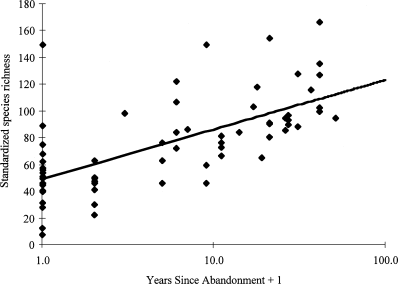

**Figure 1**

*Overall standardized species richness relative to mature tropical forest. Each point represents the response of a single taxon from one study (39 data sets included).*

The only two taxa for which there were greater than five studies with some measure of species richness were birds and ants. The best‐fitting line for ant recovery was *y*= 28.9 [log(*x*+ 1)]+ 54.0 (*R*= 0.77, *p* < 0.01), where complete recovery of species richness is estimated to occur after 39 years. The best‐fitting line for the recovery of bird species richness was *y*= 42.5 [log (*x*+ 1)]+ 43.8 (*R*= 0.69, *p* < 0.01), with complete recovery after 20 years. Both the slope and intercept of the line fit to the ant and bird data were significantly different from zero ( *p* < 0.01). Slopes and intercepts of the lines fit to the ant and bird data were statistically indistinguishable ( *p* > 0.1; Fig. 2).

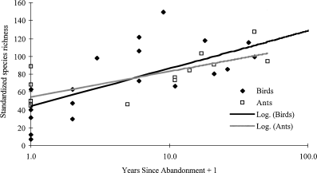

**Figure 2**

*Ant and bird standardized species richness relative to mature tropical forest. Each point represents the response of a single taxon from a single study. Ten ant and 10 bird data sets are included.*

### Species Composition: Ants and Birds

The Morisita‐Horn similarity index was provided or could be calculated for at least one comparison between secondary forest and mature forest in five ant studies and six bird studies. Like species richness, similarity of both bird and ant assemblages to mature forest assemblages was initially reduced by forest clearance and then slowly recovered. The best‐fitting line for ant recovery was *y*= 0.15 [log (*x*+ 1)]+ 0.19 (*R*= 0.69). The best‐fitting line for the recovery of birds was *y*= 0.26 [log (*x*+ 1)]+ 0.12 (*R*= 0.75). For both ants and birds, both the intercept and slope of the best‐fitting line were significantly different than zero ( *p* < 0.001). The intercepts ( *p*= 0.17) and slopes (*p*= 0.13) of the lines fit to the ant and bird data were statistically indistinguishable.

In three bird studies and four ant studies, there was sufficient replication to compare the similarity of mature forest by secondary forest pairs and mature forest by mature forest pairs. In three of the four ant studies and three of three bird studies, secondary forests were less similar to mature forests than were other mature forests to mature forests (Table 1). I included data from Bolton & Belshaw (1993) in Table 1 but not in Fig. 3 (and corresponding analyses) because Bolton and Belshaw (1993) did not provide enough information with which to calculate Morisita‐Horn values.

Table 1. **Recovery of ant and bird species composition in secondary tropical forests.**

[output not shown]

- *Rank order of similarity indicates whether the similarity of ants or birds in secondary forests to that in mature forests equaled the similarity among mature forests (MF) within a site. For example, MF × MF > SF × MF indicates that pairs of mature forests were more similar than were mature forest stands and secondary forest stands. Indices of similarity used vary among studies. Age of secondary forest (SF) is the age of oldest secondary forest sampled in study.

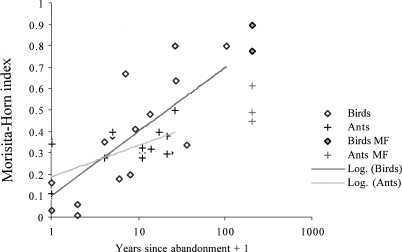

**Figure 3**

*Morisita‐Horn percent similarity to mature forest. Higher values indicate a greater resemblance to the species composition of mature forest (maximum, 1). Each point represents the response of a single taxon from a single study (six bird data sets and five ant data sets included). Where multiple comparisons were possible (e.g., comparisons of multiple secondary forests to multiple mature forests), average values were used.*

## Discussion

My results represent the recovery of a number of animal taxa under what are largely optimal conditions, when source populations are nearby and forest clearance is on a small scale and of low intensity. Under these conditions, recovery of the species richness of the taxa considered occurred in approximately 20–40 years, roughly the same amount of time as for tree species richness (Uhl et al. 1988; Guariguata & Ostertag 2000). In the first 30 years of forest regeneration, species richness of the taxa considered increased asymptotically to mature‐forest levels. Unfortunately, there are too few data from old, secondary forests to know how animal species richness changes after 30 years of forest regeneration. To the degree to which ecosystem processes are a function of species richness as opposed to species composition (e.g., Lehman & Tilman 2000), secondary forests are likely to conserve many ecological processes as well as species.

At least for ants and birds, however, species composition appears to recover more slowly than species richness. In all but one of the studies included here in the analyses of the species composition of ants or birds, the similarity between secondary forests and mature forests never reached that among mature forests, even though the measure of recovery I used was biased toward finding recovery. In none of the bird studies considered here did the authors find that similarity of secondary forests to mature forests approached that among mature forests. Even after 100 years of forest regeneration, Shankar Raman et al. (1998) found that some mature‐forest species were still missing from secondary forests. Longer‐term studies are necessary before we can know exactly how long the recovery of bird species composition may take or whether human disturbance leaves a persistent effect on the bird community. Similar to the case for birds, most results from ant studies showed that ant species composition had not recovered in secondary forests. Different taxa may recover at different rates during forest regeneration; however, there were no compelling differences between the recovery patterns of ants and birds. More host‐specific taxa, such as pollinators and parasites, have been hypothesized to recover particularly slowly but have gone relatively unstudied (Kruess & Tscharntke 1994; Cunningham 2000; Kruess & Tscharntke 2000).

Species‐occurrence data such as those I used can hide other important differences in animal communities among sites, especially for mobile animals such as birds. For example, a bird species may be seen in a secondary forest, even though it may not breed there. It is possible that for mobile taxa such as those of birds and small mammals, secondary forests are feeding but not breeding areas (Petit et al. 1999). Ants and plants, because they are colonial and relatively stationary organisms, may be better measures of the species that actually live in secondary forests, rather than those that are just passing through.

Variation in species richness and composition not explained by forest age, taxon, or differences in sampling methods may be attributable to the land‐use history of sites. Land‐use history can be an important explanation of differences in the vegetative recovery of sites (Guariguata & Ostertag 2000). Studies of single sites have shown that recovery of species composition can be affected in the short term by even relatively small differences in land‐use history (Borges & Stouffer 1999; Davies et al. 1999). Larger‐scale, more intensive disturbances may even permanently impede succession (Nepstad et al. 1991) and fail to attract seed‐dispersing animals (Wunderle 1997; Chapman & Chapman 2000). The importance and dynamics of land‐use history in the recovery of animal communities during succession is an area particularly in need of more investigation.

Secondary forests are often ignored when reserves and conservation areas are planned, except as buffer zones around protected areas. My results indicate that under optimal conditions the species richness of many taxa may recover relatively rapidly in secondary forests, although recovery of species composition may take longer. In the long term, current investment in the conservation of secondary forests may represent a conservation bargain because secondary forests grow into mature forests. Similarly, in the growing number of regions where only secondary forests remain, allocating resources to the conservation of secondary forests may still conserve a substantial percentage of some taxa. Because some species are still absent even in relatively old secondary forests, however, regions where no mature forest is left may have permanently lost many species. Therefore, the acquisition and protection of mature forests should remain a high conservation priority.

## Acknowledgments

I thank M. Wall, S. Spector, R. K. Colwell, R. Chazdon, B. McComb, G. Meffe, and one anonymous reviewer for helpful comments on the manuscript. M. Sanchez provided help throughout this project. I am grateful to J. G. Blake and H. Vasconcelos for making their data available. This study was supported by a predoctoral fellowship from the National Science Foundation and a Penner Grant from the University of Connecticut.

## Appendix 1

Table 2. **Forest type, taxon, and site information for each data set used in the study.**

[output not shown]

- <sup>*a*</sup> *Data sets with the same number in parentheses pertain to the same field site.*
- <sup>*b*</sup> *Forest types: HT, humid tropical; MSD, moist semideciduous; SD, semideciduous; CF, cloud forest; ST, subtropical; DT, dry tropical.*
- <sup>*c*</sup> *Ages of sites represent years since abandonment; MF, mature forest; CA, cleared area.*
- <sup>*d*</sup> *Clearance type indicates original reason that mature forest was cleared from sites.*
- <sup>*e*</sup> *Analyses indicates in which analyses each data set was included; div., analyses of diversity and species richness; sim., analyses of species composition and similarity.*
- <sup>*f*</sup> *Diversity indicates how diversity was measured in each study; SD, species density or species count; SR, species richness.*
- <sup>*g*</sup> *Cases where I estimated species richness from rarefaction curves provided in the original paper.*

[Volume18, Issue2](https://conbio.onlinelibrary.wiley.com/toc/15231739/2004/18/2)

April 2004

Pages 302-309